# Supply Chain Analytics – Demand Forecasting & Anomaly Detection.

## Day 9 - Model Enhancement / Advanced Forecasting & Business Insights.

```python
# Load required libraries & Load Final 90-Day Demand Forecast

import pandas as pd
import numpy as np
import matplotlib.pyplot as plt
import seaborn as sns

# Final 90-day forecast file
forecast_path = r"C:\Users\LENOVO\Desktop\Supply-Chain-Demand-Forecasting-Anomaly-Detection\data\processed\90_day_demand_forecast.csv"

forecast_df = pd.read_csv(forecast_path)

# Convert Date column to datetime
forecast_df["Date"] = pd.to_datetime(forecast_df["Date"])

print("Final 90-Day Forecast Loaded Successfully")
print("=" * 60)

print("Shape :", forecast_df.shape)

print("\nColumns:")
print(forecast_df.columns.tolist())

print("\nDate Range:")
print("Start :", forecast_df["Date"].min())
print("End   :", forecast_df["Date"].max())

print("\nMissing Values:")
print(forecast_df.isnull().sum().sum())

print("\nDuplicate Rows:")
print(forecast_df.duplicated().sum())

print("\nForecast Summary:")
print(forecast_df["Forecasted_Demand"].describe())

print("\nForecast Sample:")
display(forecast_df.head(10))
```

```
Final 90-Day Forecast Loaded Successfully
============================================================
Shape : (90, 2)

Columns:
['Date', 'Forecasted_Demand']

Date Range:
Start : 2024-12-31 00:00:00
End   : 2025-03-30 00:00:00

Missing Values:
0

Duplicate Rows:
0

Forecast Summary:
count      90.000000
mean     4943.109127
std         5.139227
min      4906.857143
25%      4943.785560
50%      4943.785714
75%      4943.785779
max      4953.758723
Name: Forecasted_Demand, dtype: float64

Forecast Sample:
```

|  | Date | Forecasted_Demand |
| --- | --- | --- |
| 0 | 2024-12-31 | 4906.857143 |
| 1 | 2025-01-01 | 4923.265306 |
| 2 | 2025-01-02 | 4925.303207 |
| 3 | 2025-01-03 | 4945.346522 |
| 4 | 2025-01-04 | 4952.538883 |
| 5 | 2025-01-05 | 4953.758723 |
| 6 | 2025-01-06 | 4947.152826 |
| 7 | 2025-01-07 | 4936.317516 |
| 8 | 2025-01-08 | 4940.526140 |
| 9 | 2025-01-09 | 4942.991974 |

```python
# Load Historical Feature-Engineered Dataset

import pandas as pd
import os

feature_engineered_path = r"data/processed/supply_chain_feature_engineered.csv"
historical_df = pd.read_csv(feature_engineered_path)

historical_df["Date"] = pd.to_datetime(historical_df["Date"])

print("Historical Feature-Engineered Dataset Loaded Successfully")
print("=" * 55)

print("Shape :", historical_df.shape)

print("\nDate Range:")
print("Start :", historical_df["Date"].min())
print("End   :", historical_df["Date"].max())

print("\nMissing Values :", historical_df.isnull().sum().sum())
print("Duplicate Rows :", historical_df.duplicated().sum())

print("\nAvailable SKUs :", historical_df["SKU_ID"].nunique())
print("Available Warehouses :", historical_df["Warehouse_ID"].nunique())

print("\nSample:")
display(historical_df.head())
```

```
Historical Feature-Engineered Dataset Loaded Successfully
=======================================================
Shape : (83750, 33)

Date Range:
Start : 2024-01-31 00:00:00
End   : 2024-12-30 00:00:00

Missing Values : 0
Duplicate Rows : 0

Available SKUs : 50
Available Warehouses : 5

Sample:
```

|  | Date | SKU_ID | Warehouse_ID | Supplier_ID | Region | Units_Sold | Inventory_Level | Supplier_Lead_Time_Days | Reorder_Point | Order_Quantity | ... | Demand_Lag_7 | Demand_Lag_14 | Demand_Lag_30 | Demand_Rolling_Mean_7 | Demand_Rolling_Mean_14 | Demand_Rolling_Mean_30 | Inventory_Demand_Ratio | Inventory_Gap | Forecast_Error | Absolute_Forecast_Error |
| --- | --- | --- | --- | --- | --- | --- | --- | --- | --- | --- | --- | --- | --- | --- | --- | --- | --- | --- | --- | --- | --- |
| 0 | 2024-01-31 | SKU_1 | WH_1 | SUP_8 | West | 18 | 754 | 14 | 379 | 397 | ... | 24.0 | 26.0 | 10.0 | 24.714286 | 24.214286 | 23.233333 | 30.508671 | 375 | 3.06 | 3.06 |
| 1 | 2024-02-01 | SKU_1 | WH_1 | SUP_8 | South | 34 | 720 | 14 | 379 | 0 | ... | 20.0 | 22.0 | 17.0 | 23.857143 | 23.642857 | 23.500000 | 30.179641 | 341 | 0.46 | 0.46 |
| 2 | 2024-02-02 | SKU_1 | WH_1 | SUP_8 | West | 24 | 696 | 14 | 379 | 0 | ... | 20.0 | 28.0 | 35.0 | 25.857143 | 24.500000 | 24.066667 | 26.917127 | 317 | -1.21 | 1.21 |
| 3 | 2024-02-03 | SKU_1 | WH_1 | SUP_8 | South | 22 | 674 | 14 | 379 | 0 | ... | 28.0 | 17.0 | 24.0 | 26.428571 | 24.214286 | 23.700000 | 25.502703 | 295 | 0.44 | 0.44 |
| 4 | 2024-02-04 | SKU_1 | WH_1 | SUP_8 | North | 32 | 642 | 14 | 379 | 0 | ... | 29.0 | 25.0 | 21.0 | 25.571429 | 24.571429 | 23.633333 | 25.106145 | 263 | 5.02 | 5.02 |

5 rows × 33 columns

```python
# Create Historical Daily Demand

historical_daily_demand = (
    historical_df
    .groupby("Date", as_index=False)["Units_Sold"]
    .sum()
    .rename(columns={"Units_Sold": "Total_Demand"})
    .sort_values("Date")
    .reset_index(drop=True)
)

print("Historical Daily Demand Created Successfully")
print("=" * 60)

print("Shape :", historical_daily_demand.shape)

print("\nDate Range:")
print("Start :", historical_daily_demand["Date"].min())
print("End   :", historical_daily_demand["Date"].max())

print("\nMissing Values :", historical_daily_demand.isnull().sum().sum())
print("Duplicate Rows :", historical_daily_demand.duplicated().sum())

print("\nDaily Demand Summary:")
print(historical_daily_demand["Total_Demand"].describe())

print("\nSample:")
display(historical_daily_demand.head())
```

```
Historical Daily Demand Created Successfully
============================================================
Shape : (335, 2)

Date Range:
Start : 2024-01-31 00:00:00
End   : 2024-12-30 00:00:00

Missing Values : 0
Duplicate Rows : 0

Daily Demand Summary:
count     335.000000
mean     4953.794030
std      1883.471423
min      2294.000000
25%      3139.000000
50%      4665.000000
75%      6899.500000
max      7702.000000
Name: Total_Demand, dtype: float64

Sample:
```

|  | Date | Total_Demand |
| --- | --- | --- |
| 0 | 2024-01-31 | 6223 |
| 1 | 2024-02-01 | 6346 |
| 2 | 2024-02-02 | 6270 |
| 3 | 2024-02-03 | 6434 |
| 4 | 2024-02-04 | 6335 |

```python
# Combine Historical Demand with 90-Day Forecast

# Historical demand
historical_timeline = historical_daily_demand.copy()

historical_timeline["Data_Type"] = "Historical"

# Future forecast
forecast_timeline = forecast_df.copy()

forecast_timeline = forecast_timeline.rename(
    columns={"Forecasted_Demand": "Total_Demand"}
)

forecast_timeline["Data_Type"] = "Forecast"

# Keep only required columns
forecast_timeline = forecast_timeline[
    ["Date", "Total_Demand", "Data_Type"]
]

historical_timeline = historical_timeline[
    ["Date", "Total_Demand", "Data_Type"]
]

# Combine both datasets
combined_demand_timeline = pd.concat(
    [historical_timeline, forecast_timeline],
    ignore_index=True
)

# Sort chronologically
combined_demand_timeline = (
    combined_demand_timeline
    .sort_values("Date")
    .reset_index(drop=True)
)

print("Historical + Forecast Timeline Created Successfully")
print("=" * 65)

print("Combined Shape :", combined_demand_timeline.shape)

print("\nDate Range:")
print("Start :", combined_demand_timeline["Date"].min())
print("End   :", combined_demand_timeline["Date"].max())

print("\nData Type Counts:")
print(combined_demand_timeline["Data_Type"].value_counts())

print("\nMissing Values:")
print(combined_demand_timeline.isnull().sum())

print("\nDuplicate Dates:")
print(combined_demand_timeline["Date"].duplicated().sum())

print("\nLast Historical Records:")
display(
    combined_demand_timeline[
        combined_demand_timeline["Data_Type"] == "Historical"
    ].tail()
)

print("\nFirst Forecast Records:")
display(
    combined_demand_timeline[
        combined_demand_timeline["Data_Type"] == "Forecast"
    ].head()
)
```

```
Historical + Forecast Timeline Created Successfully
=================================================================
Combined Shape : (425, 3)

Date Range:
Start : 2024-01-31 00:00:00
End   : 2025-03-30 00:00:00

Data Type Counts:
Data_Type
Historical    335
Forecast       90
Name: count, dtype: int64

Missing Values:
Date            0
Total_Demand    0
Data_Type       0
dtype: int64

Duplicate Dates:
0

Last Historical Records:
```

|  | Date | Total_Demand | Data_Type |
| --- | --- | --- | --- |
| 330 | 2024-12-26 | 4785.0 | Historical |
| 331 | 2024-12-27 | 4895.0 | Historical |
| 332 | 2024-12-28 | 4944.0 | Historical |
| 333 | 2024-12-29 | 5000.0 | Historical |
| 334 | 2024-12-30 | 5023.0 | Historical |

```
First Forecast Records:
```

|  | Date | Total_Demand | Data_Type |
| --- | --- | --- | --- |
| 335 | 2024-12-31 | 4906.857143 | Forecast |
| 336 | 2025-01-01 | 4923.265306 | Forecast |
| 337 | 2025-01-02 | 4925.303207 | Forecast |
| 338 | 2025-01-03 | 4945.346522 | Forecast |
| 339 | 2025-01-04 | 4952.538883 | Forecast |

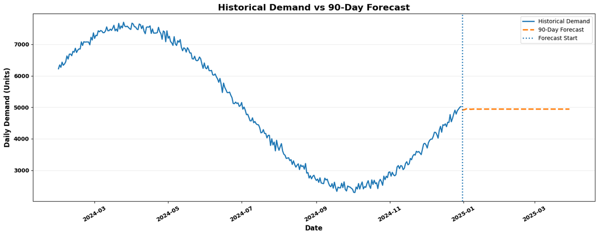

```python
# Historical vs Forecast Demand Trend

import matplotlib.pyplot as plt

plt.figure(figsize=(15, 6))

# Historical demand
historical_data = combined_demand_timeline[
    combined_demand_timeline["Data_Type"] == "Historical"
]

# Forecast demand
forecast_data = combined_demand_timeline[
    combined_demand_timeline["Data_Type"] == "Forecast"
]

# Plot historical demand
plt.plot(
    historical_data["Date"],
    historical_data["Total_Demand"],
    linewidth=2,
    label="Historical Demand"
)

# Plot forecast demand
plt.plot(
    forecast_data["Date"],
    forecast_data["Total_Demand"],
    linewidth=2.5,
    linestyle="--",
    label="90-Day Forecast"
)

# Forecast start marker
plt.axvline(
    forecast_data["Date"].min(),
    linestyle=":",
    linewidth=2,
    label="Forecast Start"
)

plt.title(
    "Historical Demand vs 90-Day Forecast",
    fontsize=16,
    fontweight="bold",
    color="black"
)

plt.xlabel(
    "Date",
    fontsize=12,
    fontweight="bold",
    color="black"
)

plt.ylabel(
    "Daily Demand (Units)",
    fontsize=12,
    fontweight="bold",
    color="black"
)

# Bold and dark axis tick values
plt.xticks(
    fontsize=10,
    fontweight="bold",
    color="black",
    rotation=30
)

plt.yticks(
    fontsize=10,
    fontweight="bold",
    color="black"
)

plt.grid(
    axis="y",
    alpha=0.25
)

plt.legend(
    fontsize=10
)

plt.tight_layout()
plt.show()
```

```python
# 90-Day Forecast Stability Analysis

forecast_values = forecast_df["Forecasted_Demand"]

forecast_mean = forecast_values.mean()
forecast_std = forecast_values.std()
forecast_min = forecast_values.min()
forecast_max = forecast_values.max()

forecast_range = forecast_max - forecast_min
coefficient_of_variation = (forecast_std / forecast_mean) * 100

print("90-Day Forecast Stability Analysis")
print("=" * 60)

print(f"Average Forecasted Demand      : {forecast_mean:.2f}")
print(f"Forecast Standard Deviation    : {forecast_std:.2f}")
print(f"Minimum Forecasted Demand      : {forecast_min:.2f}")
print(f"Maximum Forecasted Demand      : {forecast_max:.2f}")
print(f"Forecast Range                 : {forecast_range:.2f}")
print(f"Coefficient of Variation (CV)  : {coefficient_of_variation:.2f}%")

if coefficient_of_variation < 5:
    stability_status = "Highly Stable"
elif coefficient_of_variation < 10:
    stability_status = "Moderately Stable"
else:
    stability_status = "Highly Variable"

print(f"\nForecast Stability Status     : {stability_status}")
```

```
90-Day Forecast Stability Analysis
============================================================
Average Forecasted Demand      : 4943.11
Forecast Standard Deviation    : 5.14
Minimum Forecasted Demand      : 4906.86
Maximum Forecasted Demand      : 4953.76
Forecast Range                 : 46.90
Coefficient of Variation (CV)  : 0.10%

Forecast Stability Status     : Highly Stable
```

```python
# First 7 Days vs Last 7 Days Forecast Comparison

first_7_days = forecast_df.head(7)["Forecasted_Demand"]
last_7_days = forecast_df.tail(7)["Forecasted_Demand"]

first_7_avg = first_7_days.mean()
last_7_avg = last_7_days.mean()

forecast_change = last_7_avg - first_7_avg
forecast_change_pct = (forecast_change / first_7_avg) * 100

print("Forecast Period Comparison")
print("=" * 60)

print(f"First 7-Day Average Demand : {first_7_avg:.2f}")
print(f"Last 7-Day Average Demand  : {last_7_avg:.2f}")

print(f"\nAbsolute Change             : {forecast_change:.2f}")
print(f"Percentage Change           : {forecast_change_pct:.2f}%")

if forecast_change_pct > 1:
    trend_status = "Increasing"
elif forecast_change_pct < -1:
    trend_status = "Decreasing"
else:
    trend_status = "Stable"

print(f"\n90-Day Forecast Trend       : {trend_status}")
```

```
Forecast Period Comparison
============================================================
First 7-Day Average Demand : 4936.32
Last 7-Day Average Demand  : 4943.79

Absolute Change             : 7.47
Percentage Change           : 0.15%

90-Day Forecast Trend       : Stable
```

```python
# Forecast-Based Inventory Planning Benchmarks

average_daily_demand = forecast_df["Forecasted_Demand"].mean()

minimum_daily_demand = forecast_df["Forecasted_Demand"].min()
maximum_daily_demand = forecast_df["Forecasted_Demand"].max()

weekly_demand = average_daily_demand * 7
monthly_demand = average_daily_demand * 30
quarterly_demand = average_daily_demand * 90

peak_vs_average = (
    (maximum_daily_demand - average_daily_demand)
    / average_daily_demand
) * 100

print("Forecast-Based Inventory Planning Benchmarks")
print("=" * 65)

print(f"Average Daily Demand       : {average_daily_demand:.2f} units")
print(f"Minimum Daily Demand       : {minimum_daily_demand:.2f} units")
print(f"Maximum Daily Demand       : {maximum_daily_demand:.2f} units")

print(f"\nEstimated 7-Day Demand     : {weekly_demand:.2f} units")
print(f"Estimated 30-Day Demand    : {monthly_demand:.2f} units")
print(f"Estimated 90-Day Demand    : {quarterly_demand:.2f} units")

print(f"\nPeak vs Average Difference : {peak_vs_average:.2f}%")
```

```
Forecast-Based Inventory Planning Benchmarks
=================================================================
Average Daily Demand       : 4943.11 units
Minimum Daily Demand       : 4906.86 units
Maximum Daily Demand       : 4953.76 units

Estimated 7-Day Demand     : 34601.76 units
Estimated 30-Day Demand    : 148293.27 units
Estimated 90-Day Demand    : 444879.82 units

Peak vs Average Difference : 0.22%
```

```python
# Final Forecast Business Insights

print("FINAL FORECAST BUSINESS INSIGHTS")
print("=" * 70)

print("\n1. FORECAST PERFORMANCE")
print("-" * 70)
print("Selected Model : 7-Day Moving Average")
print("MAE            : 147.29")
print("RMSE           : 169.11")
print("MAPE           : 3.93%")

print("\n2. FORECAST STABILITY")
print("-" * 70)
print(f"Average Daily Demand : {average_daily_demand:.2f} units")
print(f"Forecast CV          : {coefficient_of_variation:.2f}%")
print(f"Forecast Status      : {stability_status}")

print("\n3. FORECAST TREND")
print("-" * 70)
print(f"First 7-Day Average : {first_7_avg:.2f} units")
print(f"Last 7-Day Average  : {last_7_avg:.2f} units")
print(f"Overall Change      : {forecast_change:.2f} units")
print(f"Change Percentage   : {forecast_change_pct:.2f}%")
print(f"Trend Status        : {trend_status}")

print("\n4. DEMAND PLANNING")
print("-" * 70)
print(f"7-Day Demand Benchmark  : {weekly_demand:.2f} units")
print(f"30-Day Demand Benchmark : {monthly_demand:.2f} units")
print(f"90-Day Demand Benchmark : {quarterly_demand:.2f} units")

print("\n5. BUSINESS RECOMMENDATION")
print("-" * 70)
print(
    "Maintain stable replenishment and procurement planning "
    "around the forecasted demand level while monitoring "
    "inventory, lead time and anomaly indicators."
)
```

```
FINAL FORECAST BUSINESS INSIGHTS
======================================================================

1. FORECAST PERFORMANCE
----------------------------------------------------------------------
Selected Model : 7-Day Moving Average
MAE            : 147.29
RMSE           : 169.11
MAPE           : 3.93%

2. FORECAST STABILITY
----------------------------------------------------------------------
Average Daily Demand : 4943.11 units
Forecast CV          : 0.10%
Forecast Status      : Highly Stable

3. FORECAST TREND
----------------------------------------------------------------------
First 7-Day Average : 4936.32 units
Last 7-Day Average  : 4943.79 units
Overall Change      : 7.47 units
Change Percentage   : 0.15%
Trend Status        : Stable

4. DEMAND PLANNING
----------------------------------------------------------------------
7-Day Demand Benchmark  : 34601.76 units
30-Day Demand Benchmark : 148293.27 units
90-Day Demand Benchmark : 444879.82 units

5. BUSINESS RECOMMENDATION
----------------------------------------------------------------------
Maintain stable replenishment and procurement planning around the forecasted demand level while monitoring inventory, lead time and anomaly indicators.
```

# Supply Chain Demand Forecasting & Anomaly Detection

## Day –9 :- Demand Forecasting & Business Insights

### Objective

Develop and evaluate demand forecasting models and generate a reliable 90-day demand forecast to support inventory, procurement, and replenishment planning.

### 1. Historical Demand Preparation

- Loaded the final feature-engineered supply chain dataset.
- Dataset shape: **83,750 rows × 33 columns**
- Created historical daily demand aggregation.
- Historical demand period:
  - Start: **2024-01-31**
  - End: **2024-12-30**
- Generated **335 daily demand observations**.

### 2. Forecasting Dataset Preparation

- Created a chronological train-test split.
- Historical demand was divided into:
  - Training: **268 observations**
  - Testing: **67 observations**
- Maintained chronological order to prevent data leakage.

### 3. Baseline Forecasting Models

Evaluated:

- **7-Day Moving Average**
- **30-Day Moving Average**

Performance:

| Model | MAE | RMSE | MAPE |
| --- | --- | --- | --- |
| 7-Day Moving Average | 147.29 | 169.11 | 3.93% |
| 30-Day Moving Average | 476.63 | 505.14 | 12.47% |

The **7-Day Moving Average** achieved the lowest RMSE and was selected as the best baseline forecasting model.

### 4. ARIMA Forecasting

Implemented and evaluated **ARIMA(1,1,1)**.

Performance:

- MAE: **1053.89**
- RMSE: **1264.51**
- MAPE: **25.74%**

ARIMA performed worse than the 7-Day Moving Average on the selected test period.

### 5. Final Forecast Model Selection

Final model selected:

**7-Day Moving Average**

Reason:

- Lowest MAE
- Lowest RMSE
- Lowest MAPE

### 6. 90-Day Demand Forecast

Generated a recursive **90-day future demand forecast**.

Forecast period:

- Start: **2024-12-31**
- End: **2025-03-30**

Forecast statistics:

- Average Demand: **4,943.11 units/day**
- Minimum: **4,906.86 units/day**
- Maximum: **4,953.76 units/day**
- Standard Deviation: **5.14**
- Coefficient of Variation: **0.10%**

### 7. Forecast Stability Analysis

The forecast was classified as:

**Highly Stable**

First 7-Day Average: **4,936.32 units**

Last 7-Day Average: **4,943.79 units**

Overall change: **+7.47 units / +0.15%**

Therefore, demand is expected to remain broadly stable throughout the forecast horizon.

### 8. Inventory & Demand Planning Benchmarks

Estimated demand benchmarks:

- 7-Day Demand: **34,601.76 units**
- 30-Day Demand: **148,293.27 units**
- 90-Day Demand: **444,879.82 units**

These values provide demand-planning benchmarks for procurement and replenishment decisions.

### 9. Historical + Forecast Timeline

Combined:

- **335 historical observations**
- **90 forecast observations**
- Total: **425 observations**

Validated:

- Missing values: **0**
- Duplicate dates: **0**
- Continuous historical-to-forecast timeline maintained.

### 10. Business Insight

The selected forecasting model indicates relatively stable future demand around **4.9K–5.0K units per day**. This supports predictable procurement and replenishment planning while inventory levels, supplier lead times, and previously detected anomalies should continue to be monitored.

### Key Outcome

The forecasting stage successfully produced a validated **90-day demand forecast** using the best-performing **7-Day Moving Average model**, providing a practical foundation for supply-chain planning and the final business intelligence stage.